# F015011

### **Exploring Convolutional Neural Network Architectures for Classification using Pytorch**

This notebook demonstrates the process of training deep neural network architectures for a simple classification task using a deep learning framework such as Pytorch.

### Objectives

The primary objective of this notebook is to experiment with training convolutional networks to classify a given dataset, utilising three different neural architectures and two different configuration parameters for each. Specifically, we will be experimenting with convolutional networks to classify the CIFAR-10 dataset, which consists of 60,000 32x32 pixel color images in 10 classes. To gain insights into the performance of the models, we will analyse and compare the results with various visualisations such as loss graphs and confusion matrices. Through this analysis, we aim to draw meaningful conclusions and gain a deeper understanding of the effectiveness of different neural network architectures and configuration parameters for classification tasks.

### Imports

- `import torch`: This is the main PyTorch library that provides the building blocks for defining and training neural networks.
- `import torchvision`: This is a PyTorch package that provides popular datasets, model architectures, and image transformations for computer vision tasks.
- `import torch.nn as nn`: This provides a set of predefined neural network layers and functions, such as convolutional layers, linear layers, activation functions, loss functions, and more.
- `import torch.nn.functional as F`: This provides a set of neural network functions, such as activation functions, pooling functions, and more. These functions are similar to the ones in nn, but they don't have any parameters (i.e., they are stateless).
- `import torchvision.transforms as transforms`: This provides a set of image transformations that can be applied to the input images, such as resizing, cropping, flipping, and normalizing.
- `from torch.utils.data import SubsetRandomSampler`: This provides a class that can be used to create a random subset of a dataset, which can be useful for creating a validation set during training.
- `import matplotlib.pyplot as plt`: This provides a set of plotting functions that can be used to visualize the training and validation losses and accuracies.
- `import numpy as np`: This provides a set of numerical functions that can be used to manipulate arrays, such as reshaping, slicing, and concatenating.
- `import torch.optim as optim`: This provides a set of optimization algorithms that can be used to update the weights of the neural network during training, such as stochastic gradient descent, Adam, and RMSprop.
- `from tqdm import tqdm`: This provides a progress bar that can be used to track the progress of the training loop.
- `from sklearn.metrics import confusion_matrix, classification_report, f1_score, precision_score, recall_score`: This provides a set of metrics that can be used to evaluate the performance of the model, such as precision, recall, F1 score, and confusion matrix.
- `from prettytable import PrettyTable`: This provides a class that can be used to create a table that displays the training and validation losses and accuracies in a nice format.

```python
import torch
import torchvision
import torch.nn as nn
import torch.nn.functional as F
import torchvision.transforms as transforms
from torch.utils.data import SubsetRandomSampler
import matplotlib.pyplot as plt
import numpy as np
import torch.optim as optim
from tqdm import tqdm
from sklearn.metrics import confusion_matrix, classification_report, f1_score, precision_score, recall_score
from prettytable import PrettyTable
```

### Loading the CIFAR-10 dataset

The following code defines a function called **load_data()** that loads the *CIFAR-10 dataset* and performs necessary data transformations to prepare it for training deep learning models. The function returns the training, validation and test data loaders, as well as the names of the classes in the dataset.

```python
# The following code is adpated from source [1]. The adaptations ino=colve creating a function to allow variable
# batch size, and splitting the training data into training and validation sets
def load_data(batch_size):
    """
    This function loads the CIFAR-10 dataset and performs data transformations.

    Returns:
    trainloader -- the training data loader
    valloader -- the validation data loader
    testloader -- the test data loader
    classes -- the class names
    """

    transform = transforms.Compose(
        [transforms.ToTensor(),
         transforms.Normalize((0.5, 0.5, 0.5), (0.5, 0.5, 0.5))])

    trainset = torchvision.datasets.CIFAR10(root='./data', train=True,
                                            download=True, transform=transform)

    # Split trainset into train and val sets
    num_train = len(trainset)
    indices = list(range(num_train))
    split = int(np.floor(0.2 * num_train))  # 20% of the data will be used for validation
    np.random.shuffle(indices)
    train_idx, val_idx = indices[split:], indices[:split]
    train_sampler = SubsetRandomSampler(train_idx)
    val_sampler = SubsetRandomSampler(val_idx)

    trainloader = torch.utils.data.DataLoader(trainset, batch_size=batch_size,
                                              sampler=train_sampler, num_workers=2)
    valloader = torch.utils.data.DataLoader(trainset, batch_size=batch_size,
                                            sampler=val_sampler, num_workers=2)

    testset = torchvision.datasets.CIFAR10(root='./data', train=False,
                                           download=True, transform=transform)
    testloader = torch.utils.data.DataLoader(testset, batch_size=batch_size,
                                             shuffle=False, num_workers=2)

    classes = ('plane', 'car', 'bird', 'cat', 'deer', 'dog', 'frog', 'horse', 'ship', 'truck')

    return trainloader, valloader, testloader, classes
# end of adapted code from source 1
# source [1] https://pytorch.org/tutorials/beginner/blitz/cifar10_tutorial.html#training-a-classifier
```

### SimpleNet Class Definition

The **SimpleNet** class is a convolutional neural network model defined using PyTorch's nn.Module class. It is designed to process 2D images with 3 color channels (RGB) and output a prediction of one of ten possible classes.

#### Forward Function

```python
# The following class implementation is adpated from source [1]. The adaptations involved reducing the complexity of the convolutional
# model by having one fully-connected layer.
class SimpleNet(nn.Module):
    """A class representing a "simple" convolutional neural network."""
    def __init__(self):
        super().__init__()  # Call parent class constructor
        self.conv1 = nn.Conv2d(3, 6, 5)  # 1st convolution layer with 3 input channels, 6 output channels, and 5x5 kernel
        self.pool = nn.MaxPool2d(2, 2)  # Max pooling layer with 2x2 kernel and stride 2
        self.conv2 = nn.Conv2d(6, 16, 5)  # 2nd convolution layer with 6 input channels, 16 output channels, and 5x5 kernel
        self.conv3 = nn.Conv2d(16, 32, 5)  # 3rd convolution layer with 16 input channels, 32 output channels, and 5x5 kernel
        self.fc1 = nn.Linear(16 * 5 * 5, 10)  # Fully connected layer with 16*5*5 input features and 10 output features

    def forward(self, x):
        x = self.pool(F.relu(self.conv1(x)))  # Apply convolution 1, ReLU activation, and max pooling
        x = self.pool(F.relu(self.conv2(x)))  # Apply convolution 2, ReLU activation, and max pooling
        x = torch.flatten(x, 1)  # Flatten output tensor to a 2D matrix
        x = F.relu(self.fc1(x))  # Apply fully connected layer and ReLU activation
        return x
# end of adapted code from source [1]
```

### LeNet-5 Class Definition

The **LeNet5** class is a convolutional neural network model defined using PyTorch's nn.Module class. It is a relatively simple network that was one of the earliest convolutional neural networks and achieved good results on the MNIST dataset.

#### Architecture

The architecture of the network consists of two sets of convolutional and max pooling layers, followed by one fully connected layer and the output layer. The first set of convolutional and max pooling layers is followed by a second set, which is then followed by a third convolutional layer. The output of the third convolutional layer is flattened before being passed through two fully connected layers.

#### Forward Function

The forward function is called when data is passed through the network. It takes an input tensor x as an argument and applies the network's layers in sequence to produce an output tensor. The torch.view function is used to flatten the output of the third convolutional layer before passing it through the fully connected layers.

```python
# The following class implementation is inspired from source [1], [2] and [3]. The conceptual working of the network
# has been understood from source [2] but source [1] has been used for reference to create a network that can
# be trained in a compatible way with the CIFAR-10 dataset. The strucure of the network is based on source [2] but
# with three convolutional layers and 2 fully connected layers.
class LeNet5(nn.Module):
    """A class representing the LeNet-5 convolutional neural network."""
    def __init__(self):
        super(LeNet5, self).__init__()
        self.conv1 = nn.Conv2d(3, 6, kernel_size=5)  # 1st convolution layer with 3 input channels, 6 output channels, and 5x5 kernel
        self.pool1 = nn.MaxPool2d(kernel_size=2, stride=2)  # Max pooling layer with 2x2 kernel and stride 2
        self.conv2 = nn.Conv2d(6, 16, kernel_size=5)  # 2nd convolution layer with 6 input channels, 16 output channels, and 5x5 kernel
        self.pool2 = nn.MaxPool2d(kernel_size=2, stride=2)  # Max pooling layer with 2x2 kernel and stride 2
        self.conv3 = nn.Conv2d(16, 120, kernel_size=5)  # 3rd convolution layer with 16 input channels, 120 output channels, and 5x5 kernel
        self.fc1 = nn.Linear(120, 84)  # Fully connected layer with 120 input features and 84 output features
        self.fc2 = nn.Linear(84, 10)  # Fully connected layer with 84 input features and 10 output features

    def forward(self, x):
        x = F.relu(self.conv1(x))  # Apply convolution 1 and ReLU activation
        x = self.pool1(x)  # Apply max pooling 1
        x = F.relu(self.conv2(x))  # Apply convolution 2 and ReLU activation
        x = self.pool2(x)  # Apply max pooling 2
        x = F.relu(self.conv3(x))  # Apply convolution 3 and ReLU activation
        x = x.view(-1, 120)  # Flatten output tensor to a 2D matrix
        x = F.relu(self.fc1(x))  # Apply fully connected layer 1 and ReLU activation
        x = self.fc2(x)  # Apply fully connected layer 2
        return x
# source [2] https://towardsdatascience.com/implementing-yann-lecuns-lenet-5-in-pytorch-5e05a0911320
# source [3] https://github.com/lychengrex/LeNet-5-Implementation-Using-Pytorch/blob/master/LeNet-5%20Implementation%20Using%20Pytorch.ipynb
```

### AlexNet Class Definition

The AlexNet class is a convolutional neural network model that was introduced in 2012 for image classification tasks. It is composed of five convolutional layers and three fully connected layers. The following is an implementation of this architecture with Pytorch.

#### Forward Function

The forward function of AlexNet takes an input tensor and applies the layers in sequence to produce an output tensor. The output of the last convolutional layer is flattened and then passed through the fully connected layers. The AdaptiveAvgPool2d function is used to ensure that the output of the last convolutional layer has a fixed size before it is flattened.

```python
# The following class implementation is inspired from source [4] and [5]. The forward function has been adapted, and the
# use of bias has been omitted. The structure of the network, however, remains broadly the same despite the layer sizes.
class AlexNet(nn.Module):
    """A class representing the AlexNet architecture for image classification."""
    def __init__(self, num_classes=10, dropout_rate=0.5):
        super(AlexNet, self).__init__()  # Call parent class constructor
        self.features = nn.Sequential(
            nn.Conv2d(3, 64, kernel_size=3, stride=2, padding=1),  # 1st convolution layer with 3 input channels, 64 output channels, 3x3 kernel, stride=2, and padding=1
            nn.ReLU(inplace=True),  # In-place ReLU activation
            nn.MaxPool2d(kernel_size=2),  # Max pooling layer with 2x2 kernel and stride 2
            nn.Conv2d(64, 192, kernel_size=3, padding=1),  # 2nd convolution layer with 64 input channels, 192 output channels, 3x3 kernel, and padding=1
            nn.ReLU(inplace=True),  # In-place ReLU activation
            nn.MaxPool2d(kernel_size=2),  # Max pooling layer with 2x2 kernel and stride 2
            nn.Conv2d(192, 384, kernel_size=3, padding=1),  # 3rd convolution layer with 192 input channels, 384 output channels, 3x3 kernel, and padding=1
            nn.ReLU(inplace=True),  # In-place ReLU activation
            nn.Conv2d(384, 256, kernel_size=3, padding=1),  # 4th convolution layer with 384 input channels, 256 output channels, 3x3 kernel, and padding=1
            nn.ReLU(inplace=True),  # In-place ReLU activation
            nn.Conv2d(256, 256, kernel_size=3, padding=1),  # 5th convolution layer with 256 input channels, 256 output channels, 3x3 kernel, and padding=1
            nn.ReLU(inplace=True),  # In-place ReLU activation
            nn.MaxPool2d(kernel_size=2),  # Max pooling layer with 2x2 kernel and stride 2
        )
        self.avgpool = nn.AdaptiveAvgPool2d((6, 6))  # Adaptive average pooling layer to output 6x6 tensor
        self.classifier = nn.Sequential(
            nn.Dropout(dropout_rate),  # Dropout layer
            nn.Linear(256 * 6 * 6, 4096),  # Fully connected layer with 256*6*6 input features and 4096 output features
            nn.ReLU(inplace=True),  # In-place ReLU activation
            nn.Dropout(dropout_rate),  # Dropout layer
            nn.Linear(4096, 4096),  # Fully connected layer with 4096 input features and 4096 output features
            nn.ReLU(inplace=True),  # In-place ReLU activation
            nn.Linear(4096, num_classes),  # Fully connected layer with 4096 input features and num_classes output features
        )

    def forward(self, x):
        x = self.features(x)  # Pass input tensor through feature extractor
        x = self.avgpool(x)  # Pass tensor through adaptive average pooling layer
        x = x.view(x.size(0), 256 * 6 * 6)  # Flatten tensor to a 2D matrix
        x = self.classifier(x)  # Pass tensor through classifier
        return x  # Return output tensor
# source [4] https://blog.paperspace.com/alexnet-pytorch/
# source [4] https://github.com/dansuh17/alexnet-pytorch/blob/master/model.py
```

### Loss Function and Optimiser

```python
# The following code has been created with reference to source [5] in order to understand how to access a range of
# optimizer algorithms.
def get_optimizer_and_criterion(model, lr, momentum, optimizer_name):
    """
    Get the criterion and optimizer for the given model, learning rate, momentum, and optimizer name.

    Args:
    - model: A PyTorch neural network model.
    - lr: A float representing the learning rate for the optimizer.
    - momentum: A float representing the momentum for the optimizer.
    - optimizer_name: A string representing the name of the optimizer to use.

    Returns:
    - criterion: The loss function to use for the model.
    - optimizer: The optimizer to use for training the model.
    """

    # define the loss function
    criterion = nn.CrossEntropyLoss()

    # set the optimizer based on the given optimizer name
    if optimizer_name == 'SGD':
        optimizer = torch.optim.SGD(model.parameters(), lr=lr, momentum=momentum, weight_decay=0.0001)
    elif optimizer_name == 'Adam':
        optimizer = torch.optim.Adam(model.parameters(), lr=lr, weight_decay=0.0001)
    elif optimizer_name == 'Adagrad':
        optimizer = torch.optim.Adagrad(model.parameters(), lr=lr, weight_decay=0.0001)
    else:
        # if an unsupported optimizer name is given, raise an error
        raise ValueError('Unsupported optimizer')

    # return the criterion and optimizer
    return criterion, optimizer

# source [6] https://pytorch.org/docs/stable/optim.html
```

### Training Function

```python
# The following training function is an adapted version of the training method used in source [1]. It has been
# adapted to perform one pass for a given epoch and packaged as a function, given a range of parameters.
def train_model(model, train_loader, lr, momentum, current_epoch, optimizer_name):
    """Train a PyTorch model on a training dataset.

    Args:
        model: The PyTorch model to be trained.
        train_loader: The PyTorch DataLoader for the training dataset.
        lr: The learning rate for the optimizer.
        momentum: The momentum value for the optimizer.
        current_epoch: The current epoch number of the training process.
        optimizer_name: The name of the optimizer to use.

    Returns:
        tuple: A tuple of the average training loss and the training accuracy.
    """

    train_losses = []

    # Check if GPU is available and move the model to the available device
    device = torch.device("cuda:0" if torch.cuda.is_available() else "cpu")

    # Move the model to the selected device
    model.to(device)

    # Get the criterion and optimizer functions based on the provided optimizer name
    criterion, optimizer = get_optimizer_and_criterion(model, lr, momentum, optimizer_name)

    # Initialize some variables for tracking the running loss and accuracy
    running_loss = 0.0
    correct = 0
    total = 0

    # Loop through each batch in the training DataLoader
    for i, data in enumerate(train_loader, 0):
        # Move the batch data to the selected device
        inputs, labels = data[0].to(device), data[1].to(device)

        # Zero out the optimizer's gradient buffers
        optimizer.zero_grad()

        # Make a forward pass through the model to get the outputs
        outputs = model(inputs)

        # Compute the loss based on the criterion function
        loss = criterion(outputs, labels)

        # Perform backpropagation to compute the gradients of the loss with respect to the model parameters
        loss.backward()

        # Use the optimizer to update the model parameters based on the computed gradients
        optimizer.step()

        # Update the running loss and accuracy metrics
        running_loss += loss.item()
        _, predicted = torch.max(outputs.data, 1)
        total += labels.size(0)
        correct += (predicted == labels).sum().item()

    # Compute the training accuracy as a percentage
    accuracy = 100 * correct / total

    # Compute the average training loss for this epoch
    avg_train_loss = running_loss / len(train_loader)

    # Add the average training loss for this epoch to the list of training losses
    train_losses.append(avg_train_loss)

    # Return a tuple of the average training loss and the training accuracy
    return avg_train_loss, accuracy
```

### Validation Function

```python
# The following validation function is an adapted version of the testing method used in source [1]. It has been
# adapted to perform one pass for a given epoch and packaged as a function, given a range of parameters.
def validate_model(model, test_loader):
    """Evaluates a PyTorch model on the validation set.

    Args:
        model (torch.nn.Module): The PyTorch model to evaluate.
        test_loader (torch.utils.data.DataLoader): A DataLoader that provides the test set.

    Returns:
        tuple: A tuple of two floats representing the average test loss and the test accuracy, respectively.

    """
    # Check if GPU is available and move the model to the available device
    device = torch.device("cuda:0" if torch.cuda.is_available() else "cpu")
    model.to(device)

    # Define the loss criterion
    criterion = nn.CrossEntropyLoss()

    # Initialize variables to keep track of the loss and accuracy
    test_loss = 0
    correct = 0
    total = 0

    # Evaluate the model on the test set
    with torch.no_grad():
        for data in test_loader:
            images, labels = data[0].to(device), data[1].to(device)
            outputs = model(images)
            loss = criterion(outputs, labels)
            test_loss += loss.item()
            _, predicted = torch.max(outputs.data, 1)
            total += labels.size(0)
            correct += (predicted == labels).sum().item()

    # Calculate the average test loss and accuracy
    avg_test_loss = test_loss / len(test_loader)
    accuracy = 100 * correct / total

    # Return the results
    return avg_test_loss, accuracy
```

### Testing Function

```python
# The following test function is an adapted version of the testing method used in source [1]. It has been
# adapted to perform one pass for a given epoch and packaged as a function, given a range of parameters.
# Further analysis metrics and visualisations have been incorporated using the sklearn.metrics model found in source [6]
from sklearn.metrics import f1_score, precision_score, recall_score, confusion_matrix

def test_model(model, test_loader):
    """Tests a PyTorch model on a test set, and reports various performance metrics.

    Args:
        model: The PyTorch model to test.
        test_loader: A DataLoader that provides the test set.

    Returns:
        tuple: A tuple of four floats representing the test accuracy, the weighted F1 score, the weighted precision, and the weighted recall, respectively.

    """
    # Set model to evaluation mode
    model.eval()

    # Initialize variables for metrics and predictions
    correct = 0
    total = 0
    all_predictions = []
    all_labels = []

    with torch.no_grad():
        # Loop over test set and evaluate the model
        for data in test_loader:
            images, labels = data
            outputs = model(images)
            _, predicted = torch.max(outputs.data, 1)
            total += labels.size(0)
            correct += (predicted == labels).sum().item()
            all_predictions.extend(predicted.tolist())
            all_labels.extend(labels.tolist())

    # Calculate various performance metrics
    accuracy = 100 * correct / total
    f1 = f1_score(all_labels, all_predictions, average='weighted')
    precision = precision_score(all_labels, all_predictions, average='weighted')
    recall = recall_score(all_labels, all_predictions, average='weighted')

    # Print performance metrics
    print(f"Accuracy of the network on the {total} test images: {accuracy:.2f}%")
    print(f"Weighted F1 score: {f1:.2f}")
    print(f"Weighted precision: {precision:.2f}")
    print(f"Weighted recall: {recall:.2f}")

    # Compute confusion matrix
    cm = confusion_matrix(all_labels, all_predictions)
    class_names = test_loader.dataset.classes
    cm_percent = cm.astype('float') / cm.sum(axis=1)[:, np.newaxis]

    # Plot confusion matrix
    fig, ax = plt.subplots(figsize=(8, 6))
    im = ax.imshow(cm_percent, interpolation='nearest', cmap=plt.cm.Blues)
    ax.set_title("Confusion matrix")
    ax.set_xticks(np.arange(len(class_names)))
    ax.set_yticks(np.arange(len(class_names)))
    ax.set_xticklabels(class_names, rotation=45, ha='right')
    ax.set_yticklabels(class_names)
    ax.set_xlabel('Predicted label')
    ax.set_ylabel('True label')

    # Loop over data dimensions and create text annotations.
    for i in range(len(class_names)):
        for j in range(len(class_names)):
            ax.text(j, i, "{:.2f}".format(cm_percent[i, j]),
                     ha="center", va="center", color="white" if cm_percent[i, j] > 0.5 else "black")

    plt.colorbar(im)
    plt.tight_layout()

    return accuracy, f1, precision, recall

# source [7] https://scikit-learn.org/stable/modules/model_evaluation.html
```

### Fitting Function

```python
def fit_model(model, num_epochs, lr, momentum, optimizer_name, trainloader, valloader):
    """Trains and validates a given PyTorch model for a certain number of epochs using the specified optimizer,
    learning rate, and momentum. Returns the trained model and various performance metrics.

    Args:
    - model: the PyTorch model to be trained and validated
    - num_epochs: the number of epochs to train the model for
    - lr: the learning rate to be used by the optimizer
    - momentum: the momentum value to be used by the optimizer
    - optimizer_name: the name of the optimizer to be used ("SGD" or "Adam")
    - trainloader: the DataLoader object containing the training dataset
    - valloader: the DataLoader object containing the validation dataset

    Returns:
    - model: the trained PyTorch model
    - training_loss: a dictionary mapping epoch number to the training loss for that epoch
    - training_acc: a dictionary mapping epoch number to the training accuracy for that epoch
    - testing_loss: a dictionary mapping epoch number to the validation loss for that epoch
    - testing_acc: a dictionary mapping epoch number to the validation accuracy for that epoch
    """
    training_loss = {}
    training_acc = {}
    testing_loss = {}
    testing_acc = {}

    # Iterate over the epochs
    for epoch in tqdm(range(num_epochs)):
        # Train the model for this epoch and record the training loss and accuracy
        training_loss[epoch], training_acc[epoch] = train_model(model, trainloader, lr, momentum, epoch, optimizer_name)
        # Validate the model for this epoch and record the validation loss and accuracy
        testing_loss[epoch], testing_acc[epoch] = validate_model(model, valloader)

    # Create a table to display the performance metrics
    table = PrettyTable()
    table.field_names = ["Epoch", "Training Loss", "Validation Loss", "Training Accuracy", "Validation Accuracy"]

    for epoch in range(num_epochs):
        # Add the performance metrics for this epoch to the table
        table.add_row([
            epoch + 1,
            f"{training_loss[epoch]:.4f}",
            f"{testing_loss[epoch]:.4f}",
            f"{training_acc[epoch]:.2f}%",
            f"{testing_acc[epoch]:.2f}%"
        ])

    # Print the performance table
    print(table)

    return model, training_loss, training_acc, testing_loss, testing_acc
```

### Plotting Function

```python
def plot_results(train_losses, test_losses, train_acc, test_acc):
    """ Plot the training and testing loss and accuracy curves."""
    fig, (ax1, ax2) = plt.subplots(ncols=2, figsize=(8, 4), sharey=False)

    ax1.plot(list(reversed(list(train_losses.keys()))), list(reversed(list(train_losses.values()))), label='Train Loss')
    ax1.plot(list(reversed(list(test_losses.keys()))), list(reversed(list(test_losses.values()))), label='Test Loss')
    ax1.set_title('Training and Testing Loss')
    ax1.set_xlabel('Epoch')
    ax1.set_ylabel('Loss')
    ax1.legend()
    ax1.set_box_aspect(1)

    ax2.plot(list(reversed(list(train_acc.keys()))), list(reversed(list(train_acc.values()))), label='Train Acc')
    ax2.plot(list(reversed(list(test_acc.keys()))), list(reversed(list(test_acc.values()))), label='Test Loss')
    ax2.set_title('Training and Testing Accuracy')
    ax2.set_xlabel('Epoch')
    ax2.set_ylabel('Accuracy')
    ax2.legend()
    ax2.set_box_aspect(1)
```

## Experiment 1 (SimpleNet)

### Learning Rate Adjustment

The following experiment seeks to demonstrate the impact of the learning rate when training our previously defined SimpleNet architecture; a series of varied learning rates will be tested, while all remaining parameters will not be altered.

**lr = 0.001**

```python
num_epochs = 12
lr = 0.001
momentum = 0.9
batch_size = 128
optimizer_name = 'SGD'
trainloader, valloader, testloader, classes = load_data(batch_size)
simple_net_a = SimpleNet()
trained_simple_net_a, training_loss_1a, training_acc_1a, testing_loss_1a, testing_acc_1a = fit_model(simple_net_a, num_epochs, lr, momentum, optimizer_name, trainloader, valloader)
```

```
Files already downloaded and verified
Files already downloaded and verified
```

```
+-------+---------------+-----------------+-------------------+---------------------+
| Epoch | Training Loss | Validation Loss | Training Accuracy | Validation Accuracy |
+-------+---------------+-----------------+-------------------+---------------------+
|   1   |     2.2795    |      2.2247     |       16.47%      |        19.92%       |
|   2   |     2.0963    |      2.0006     |       25.48%      |        29.71%       |
|   3   |     1.9350    |      1.9043     |       32.59%      |        33.95%       |
|   4   |     1.8501    |      1.8262     |       36.14%      |        36.22%       |
|   5   |     1.7890    |      1.7792     |       38.54%      |        38.30%       |
|   6   |     1.7409    |      1.7354     |       40.25%      |        40.29%       |
|   7   |     1.7049    |      1.7168     |       41.56%      |        40.80%       |
|   8   |     1.6743    |      1.6790     |       42.48%      |        42.13%       |
|   9   |     1.6478    |      1.6575     |       44.00%      |        43.57%       |
|   10  |     1.6279    |      1.6381     |       44.57%      |        43.53%       |
|   11  |     1.6071    |      1.6316     |       45.44%      |        44.02%       |
|   12  |     1.5898    |      1.6046     |       46.39%      |        45.88%       |
+-------+---------------+-----------------+-------------------+---------------------+
```

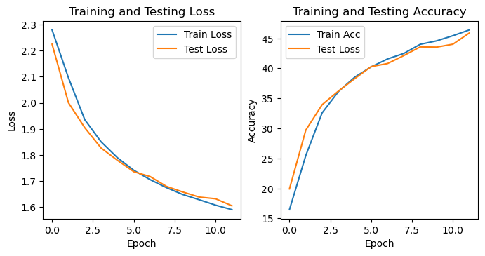

```python
plot_results(training_loss_1a, testing_loss_1a, training_acc_1a, testing_acc_1a)
```

```
Accuracy of the network on the 40000 test images: 46.81%
Weighted F1 score: 0.44
Weighted precision: 0.42
Weighted recall: 0.47
```

```
(46.81, 0.44190029402881936, 0.424936368020846, 0.4681)
```

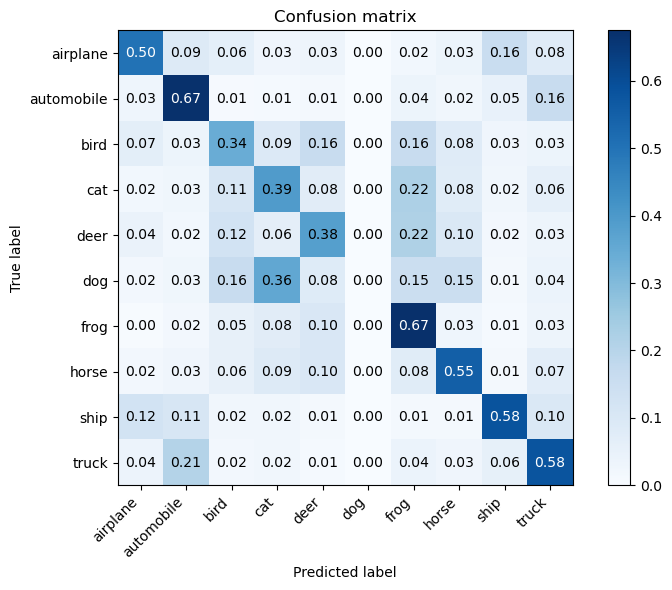

```python
test_model(trained_simple_net_a, trainloader)
```

**lr = 0.025**

```python
num_epochs = 12
lr = 0.025
momentum = 0.9
batch_size = 128
optimizer_name = 'SGD'
trainloader, valloader, testloader, classes = load_data(batch_size)
simple_net_b = SimpleNet()
trained_simple_net_1b, training_loss_1b, training_acc_1b, testing_loss_1b, testing_acc_1b = fit_model(simple_net_b, num_epochs, lr, momentum, optimizer_name, trainloader, valloader)
```

```
Files already downloaded and verified
Files already downloaded and verified
```

```
+-------+---------------+-----------------+-------------------+---------------------+
| Epoch | Training Loss | Validation Loss | Training Accuracy | Validation Accuracy |
+-------+---------------+-----------------+-------------------+---------------------+
|   1   |     1.7694    |      1.5095     |       36.93%      |        44.99%       |
|   2   |     1.3720    |      1.3164     |       51.21%      |        53.79%       |
|   3   |     1.2719    |      1.2730     |       55.28%      |        55.33%       |
|   4   |     1.2293    |      1.3239     |       56.83%      |        53.02%       |
|   5   |     1.1975    |      1.2725     |       57.88%      |        55.48%       |
|   6   |     1.1749    |      1.2327     |       58.78%      |        57.35%       |
|   7   |     1.1581    |      1.2439     |       59.33%      |        56.43%       |
|   8   |     1.1375    |      1.2116     |       60.24%      |        58.40%       |
|   9   |     1.1215    |      1.1885     |       60.91%      |        58.65%       |
|   10  |     1.1113    |      1.2074     |       61.22%      |        57.67%       |
|   11  |     1.0977    |      1.2211     |       61.83%      |        57.77%       |
|   12  |     1.1034    |      1.1623     |       61.49%      |        60.39%       |
+-------+---------------+-----------------+-------------------+---------------------+
```

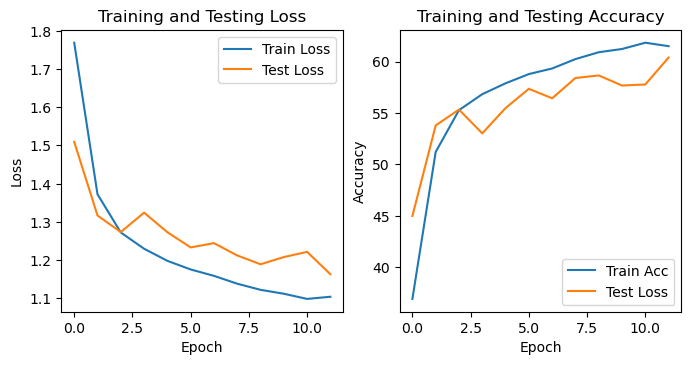

```python
plot_results(training_loss_1b, testing_loss_1b, training_acc_1b, testing_acc_1b)
```

```
Accuracy of the network on the 40000 test images: 64.33%
Weighted F1 score: 0.64
Weighted precision: 0.64
Weighted recall: 0.64
```

```
(64.335, 0.6364157508562829, 0.639928969750239, 0.64335)
```

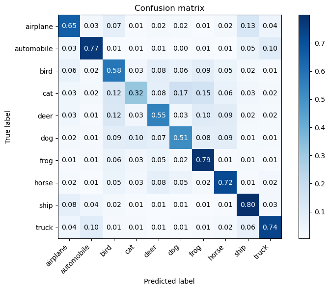

```python
test_model(trained_simple_net_1b, trainloader)
```

**lr = 0.05**

```python
num_epochs = 12
lr = 0.05
momentum = 0.9
batch_size = 128
optimizer_name = 'SGD'
trainloader, valloader, testloader, classes = load_data(batch_size)
simple_net_c = SimpleNet()
trained_simple_net_1c, training_loss_1c, training_acc_1c, testing_loss_1c, testing_acc_1c = fit_model(simple_net_c, num_epochs, lr, momentum, optimizer_name, trainloader, valloader)
```

```
Files already downloaded and verified
Files already downloaded and verified
```

```
+-------+---------------+-----------------+-------------------+---------------------+
| Epoch | Training Loss | Validation Loss | Training Accuracy | Validation Accuracy |
+-------+---------------+-----------------+-------------------+---------------------+
|   1   |     1.8384    |      1.4912     |       34.22%      |        45.66%       |
|   2   |     1.4356    |      1.3806     |       48.89%      |        51.07%       |
|   3   |     1.3430    |      1.3496     |       52.80%      |        53.07%       |
|   4   |     1.3034    |      1.3236     |       54.35%      |        53.40%       |
|   5   |     1.2892    |      1.3461     |       55.03%      |        52.77%       |
|   6   |     1.2727    |      1.3308     |       55.67%      |        53.03%       |
|   7   |     1.2364    |      1.3242     |       56.91%      |        53.71%       |
|   8   |     1.2264    |      1.2764     |       57.23%      |        54.97%       |
|   9   |     1.2245    |      1.2550     |       57.52%      |        55.99%       |
|   10  |     1.2053    |      1.2804     |       58.12%      |        55.86%       |
|   11  |     1.2009    |      1.2598     |       58.48%      |        56.38%       |
|   12  |     1.1973    |      1.3383     |       57.85%      |        53.68%       |
+-------+---------------+-----------------+-------------------+---------------------+
```

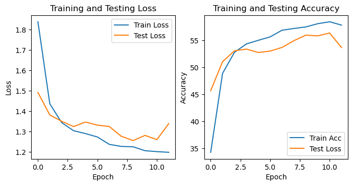

```python
plot_results(training_loss_1c, testing_loss_1c, training_acc_1c, testing_acc_1c)
```

```
Accuracy of the network on the 40000 test images: 56.30%
Weighted F1 score: 0.56
Weighted precision: 0.57
Weighted recall: 0.56
```

```
(56.3, 0.5550655837047022, 0.5716389671845729, 0.563)
```

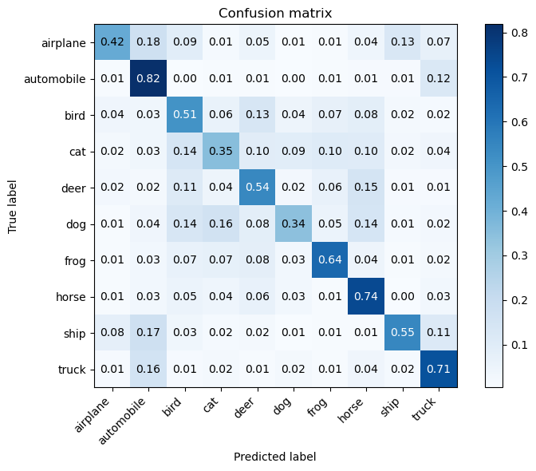

```python
test_model(trained_simple_net_1c, trainloader)
```

**lr = 0.1**

```python
num_epochs = 12
lr = 0.1
momentum = 0.9
batch_size = 128
optimizer_name = 'SGD'
trainloader, valloader, testloader, classes = load_data(batch_size)
simple_net_d = SimpleNet()
trained_simple_net_1d, training_loss_1d, training_acc_1d, testing_loss_1d, testing_acc_1d = fit_model(simple_net_d, num_epochs, lr, momentum, optimizer_name, trainloader, valloader)
```

```
Files already downloaded and verified
Files already downloaded and verified
```

```
+-------+---------------+-----------------+-------------------+---------------------+
| Epoch | Training Loss | Validation Loss | Training Accuracy | Validation Accuracy |
+-------+---------------+-----------------+-------------------+---------------------+
|   1   |     1.8631    |      1.6671     |       32.96%      |        38.86%       |
|   2   |     1.6439    |      1.5661     |       40.84%      |        44.08%       |
|   3   |     1.5729    |      1.6767     |       43.82%      |        40.47%       |
|   4   |     1.5193    |      1.6427     |       45.94%      |        43.39%       |
|   5   |     1.4746    |      1.5234     |       47.66%      |        46.53%       |
|   6   |     1.5048    |      1.6684     |       46.91%      |        41.93%       |
|   7   |     1.4898    |      1.4773     |       47.72%      |        48.96%       |
|   8   |     1.4559    |      1.5109     |       48.68%      |        46.79%       |
|   9   |     1.4474    |      1.4438     |       48.58%      |        49.31%       |
|   10  |     1.4417    |      1.4482     |       49.33%      |        49.25%       |
|   11  |     1.4460    |      1.4631     |       49.33%      |        48.61%       |
|   12  |     1.4234    |      1.4493     |       49.92%      |        49.13%       |
+-------+---------------+-----------------+-------------------+---------------------+
```

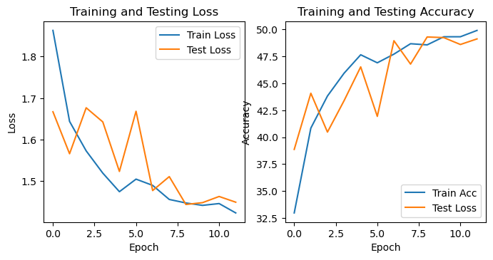

```python
plot_results(training_loss_1d, testing_loss_1d, training_acc_1d, testing_acc_1d)
```

```
Accuracy of the network on the 40000 test images: 52.40%
Weighted F1 score: 0.52
Weighted precision: 0.53
Weighted recall: 0.52
```

```
(52.4025, 0.5171558894811534, 0.5299061170460974, 0.524025)
```

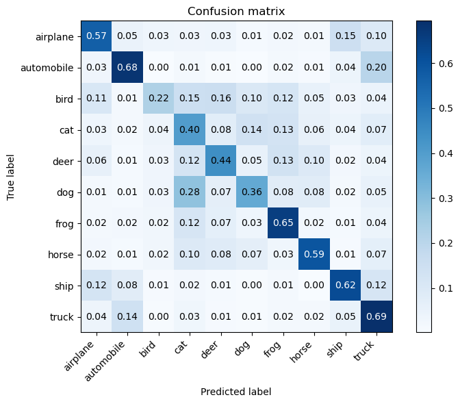

```python
test_model(trained_simple_net_1d, trainloader)
```

#### Batch Size Adjustment

**batch size = 256**

```python
num_epochs = 12
lr = 0.025
momentum = 0.9
batch_size = 256
optimizer_name = 'SGD'
trainloader, valloader, testloader, classes = load_data(batch_size)
simple_net_e = SimpleNet()
trained_simple_net_1e, training_loss_1e, training_acc_1e, testing_loss_1e, testing_acc_1e = fit_model(simple_net_e, num_epochs, lr, momentum, optimizer_name, trainloader, valloader)
```

```
Files already downloaded and verified
Files already downloaded and verified
```

```
+-------+---------------+-----------------+-------------------+---------------------+
| Epoch | Training Loss | Validation Loss | Training Accuracy | Validation Accuracy |
+-------+---------------+-----------------+-------------------+---------------------+
|   1   |     2.0656    |      1.8815     |       26.61%      |        34.37%       |
|   2   |     1.7771    |      1.6609     |       38.61%      |        42.20%       |
|   3   |     1.4512    |      1.3580     |       48.58%      |        52.24%       |
|   4   |     1.2996    |      1.2726     |       54.21%      |        54.65%       |
|   5   |     1.2260    |      1.2080     |       56.95%      |        57.24%       |
|   6   |     1.1703    |      1.1911     |       59.05%      |        58.37%       |
|   7   |     1.1354    |      1.2106     |       60.05%      |        58.05%       |
|   8   |     1.1132    |      1.1710     |       61.19%      |        59.12%       |
|   9   |     1.0962    |      1.2216     |       61.60%      |        57.44%       |
|   10  |     1.0765    |      1.1152     |       62.51%      |        61.88%       |
|   11  |     1.0554    |      1.1313     |       62.96%      |        61.63%       |
|   12  |     1.0525    |      1.1349     |       63.27%      |        61.10%       |
+-------+---------------+-----------------+-------------------+---------------------+
```

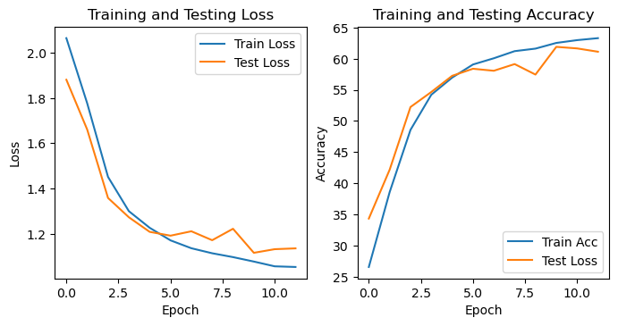

```python
plot_results(training_loss_1e, testing_loss_1e, training_acc_1e, testing_acc_1e)
```

```python
test_model(trained_simple_net_1e, trainloader)
```

[output not shown]

```
Accuracy of the network on the 40000 test images: 64.80%
Weighted F1 score: 0.65
Weighted precision: 0.67
Weighted recall: 0.65
```

```
(64.8, 0.6494118176378052, 0.6749362035051273, 0.648)
```

**batch size = 512**

```python
num_epochs = 12
lr = 0.025
momentum = 0.9
batch_size = 512
optimizer_name = 'SGD'
trainloader, valloader, testloader, classes = load_data(batch_size)
simple_net_f = SimpleNet()
trained_simple_net_1f, training_loss_1f, training_acc_1f, testing_loss_1f, testing_acc_1f = fit_model(simple_net_e, num_epochs, lr, momentum, optimizer_name, trainloader, valloader)
```

```
Files already downloaded and verified
Files already downloaded and verified
```

```
+-------+---------------+-----------------+-------------------+---------------------+
| Epoch | Training Loss | Validation Loss | Training Accuracy | Validation Accuracy |
+-------+---------------+-----------------+-------------------+---------------------+
|   1   |     1.0031    |      1.0627     |       65.17%      |        63.19%       |
|   2   |     0.9903    |      1.0283     |       65.63%      |        64.32%       |
|   3   |     0.9814    |      1.0549     |       66.08%      |        63.54%       |
|   4   |     0.9771    |      1.0395     |       66.22%      |        63.93%       |
|   5   |     0.9705    |      1.0598     |       66.16%      |        63.14%       |
|   6   |     0.9658    |      1.0089     |       66.56%      |        65.67%       |
|   7   |     0.9616    |      1.1006     |       66.68%      |        62.07%       |
|   8   |     0.9565    |      1.0195     |       66.67%      |        64.82%       |
|   9   |     0.9450    |      1.0651     |       67.33%      |        63.27%       |
|   10  |     0.9454    |      1.0622     |       67.19%      |        63.52%       |
|   11  |     0.9418    |      1.0530     |       67.19%      |        63.46%       |
|   12  |     0.9360    |      1.0784     |       67.56%      |        62.50%       |
+-------+---------------+-----------------+-------------------+---------------------+
```

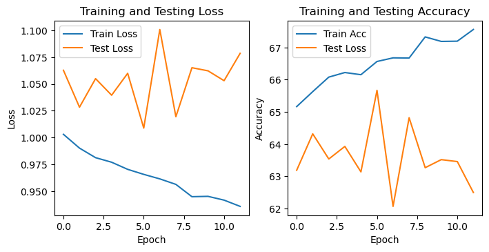

```python
plot_results(training_loss_1f, testing_loss_1f, training_acc_1f, testing_acc_1f)
```

```python
test_model(trained_simple_net_1f, trainloader)
```

[output not shown]

[output not shown]

**batch size = 1024**

```python
num_epochs = 12
lr = 0.025
momentum = 0.9
batch_size = 1024
optimizer_name = 'SGD'
trainloader, valloader, testloader, classes = load_data(batch_size)
simple_net_g = SimpleNet()
trained_simple_net_1g, training_loss_1g, training_acc_1g, testing_loss_1g, testing_acc_1g = fit_model(simple_net_e, num_epochs, lr, momentum, optimizer_name, trainloader, valloader)
```

```
Files already downloaded and verified
Files already downloaded and verified
```

```
+-------+---------------+-----------------+-------------------+---------------------+
| Epoch | Training Loss | Validation Loss | Training Accuracy | Validation Accuracy |
+-------+---------------+-----------------+-------------------+---------------------+
|   1   |     0.9434    |      0.9476     |       67.29%      |        67.54%       |
|   2   |     0.9117    |      1.0009     |       68.38%      |        65.70%       |
|   3   |     0.9143    |      1.0346     |       68.17%      |        64.39%       |
|   4   |     0.9210    |      1.0012     |       68.00%      |        65.85%       |
|   5   |     0.9174    |      0.9496     |       68.46%      |        67.35%       |
|   6   |     0.9046    |      0.9833     |       68.80%      |        66.53%       |
|   7   |     0.9008    |      0.9923     |       68.72%      |        65.35%       |
|   8   |     0.8985    |      1.0035     |       68.80%      |        65.73%       |
|   9   |     0.9064    |      1.0713     |       68.69%      |        63.67%       |
|   10  |     0.9139    |      0.9735     |       68.13%      |        66.84%       |
|   11  |     0.8903    |      1.0004     |       69.05%      |        65.69%       |
|   12  |     0.9095    |      1.0883     |       68.57%      |        62.59%       |
+-------+---------------+-----------------+-------------------+---------------------+
```

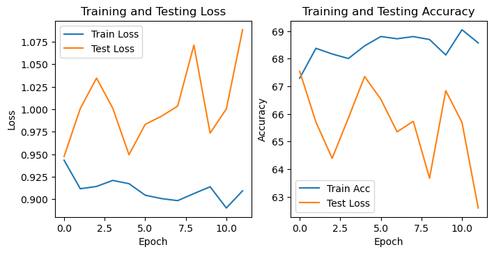

```python
plot_results(training_loss_1g, testing_loss_1g, training_acc_1g, testing_acc_1g)
```

```python
test_model(trained_simple_net_1g, trainloader)
```

[output not shown]

[output not shown]

**batch size = 64**

```python
num_epochs = 12
lr = 0.025
momentum = 0.9
batch_size = 64
optimizer_name = 'SGD'
trainloader, valloader, testloader, classes = load_data(batch_size)
simple_net_h = SimpleNet()
trained_simple_net_1h, training_loss_1h, training_acc_1h, testing_loss_1h, testing_acc_1h = fit_model(simple_net_h, num_epochs, lr, momentum, optimizer_name, trainloader, valloader)
```

```
Files already downloaded and verified
Files already downloaded and verified
```

```
+-------+---------------+-----------------+-------------------+---------------------+
| Epoch | Training Loss | Validation Loss | Training Accuracy | Validation Accuracy |
+-------+---------------+-----------------+-------------------+---------------------+
|   1   |     1.7861    |      1.5159     |       36.85%      |        45.27%       |
|   2   |     1.4234    |      1.3287     |       49.51%      |        52.67%       |
|   3   |     1.3373    |      1.3206     |       52.95%      |        52.82%       |
|   4   |     1.2971    |      1.3527     |       54.79%      |        51.55%       |
|   5   |     1.2532    |      1.2582     |       56.39%      |        56.13%       |
|   6   |     1.2460    |      1.2723     |       56.76%      |        56.17%       |
|   7   |     1.2318    |      1.2279     |       57.36%      |        57.32%       |
|   8   |     1.2133    |      1.2518     |       57.71%      |        56.57%       |
|   9   |     1.2084    |      1.2480     |       58.23%      |        57.43%       |
|   10  |     1.2027    |      1.2272     |       58.05%      |        57.21%       |
|   11  |     1.1823    |      1.2311     |       58.95%      |        57.50%       |
|   12  |     1.1923    |      1.2504     |       58.67%      |        56.59%       |
+-------+---------------+-----------------+-------------------+---------------------+
```

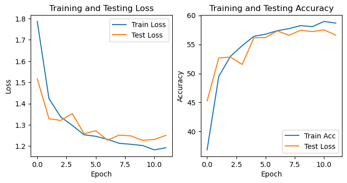

```python
plot_results(training_loss_1h, testing_loss_1h, training_acc_1h, testing_acc_1h)
```

```
Accuracy of the network on the 40000 test images: 59.31%
Weighted F1 score: 0.58
Weighted precision: 0.60
Weighted recall: 0.59
```

```
(59.31, 0.5784318796808268, 0.6008788865402683, 0.5931)
```

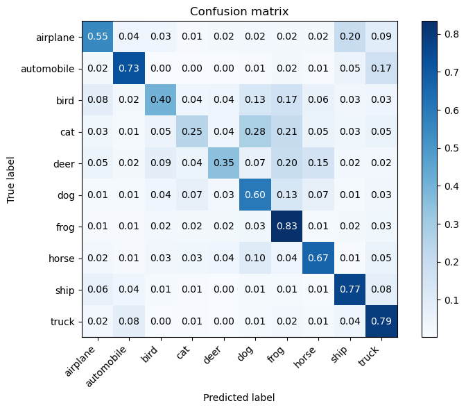

```python
test_model(trained_simple_net_1h, trainloader)
```